# HW4

Olivia Leeson

10/17/2016

# Using Bootstrapping to Exhibit CLT

*“Write bootstrap code to illustrate the central limit theorem in R markdown and push the result to GitHub. Use a normal distribution with two different sample sizes and an exponential distribution with two different sample sizes. Correct code alone is insufficient. Please also comment on the code and explain the results. For help, see the lotsa.medians function in Unit 4. The deliverable is a link to a GitHub repo containing the code.”*

### Generation of Random Samples

Our first step is to generate our random samples taken from a given population distribution. Below is the code to generate 4 different samples: 2 samples from a normal population distribution with sample size of 50 and 75 respectively, and 2 samples from an exponential distribution with sample size of 50 and 75 respectively.

```r
#random sample from normal distribution
first <- rnorm(50, mean = 10, sd =2)
second <- rnorm(75, mean=10, sd=2)

#random sample from exponential distribution
firstexp <- rexp(50)
secondexp <- rexp(75)
```

### Bootstrap Function

The function defined below is our bootstrapping function. This function will generate 1000 more random samples with replacement taken from our original random samples generated previously.

```r
#bootstrap function
#returns mean, standard deviation, and histogram of bootstrap
bootmean <- numeric()
bstrap <- function(y) {
  bootmean <- numeric(1000)
    for (i in 1:1000) {
      bootsample <- sample(y, size=length(y), replace = TRUE)
      bootmean[i] <- mean(bootsample)
      }
  print(mean(bootmean))
  print(var(bootmean))
  hist(bootmean, main="Histogram of Bootstrap Mean")
}
```

### Illustrating the Central Limit Theorem

The central limit theorem states that the sampling distribution of the mean of a distribution with a given mean (μ) and variance (σ²) will approach a normal distribution with a mean(μ) and variance of σ²/N as N increases.

The histogram of a single random sample taken from a normal distribution with a mean (μ) of 10 and a variance (σ²) of 4 is shown below.

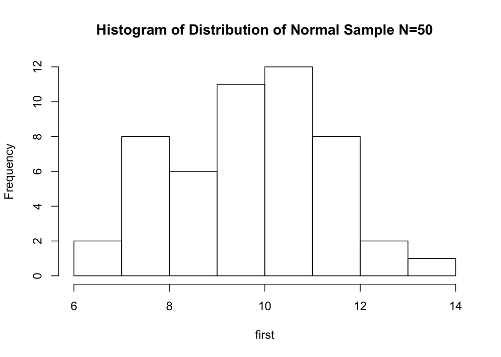

```r
#histogram of normal distribution sample 1 and bootstrap sample 1
hist(first, main="Histogram of Distribution of Normal Sample N=50")
```

We use the bootstrap method to generate 1000 more random samples generated from the values observed in our original sample with equal sample sizes of 50. We find the mean, variance, and distribution of the bootstrap.

```r
bstrap(first)
```

```
## [1] 9.6764
## [1] 0.04629555
```

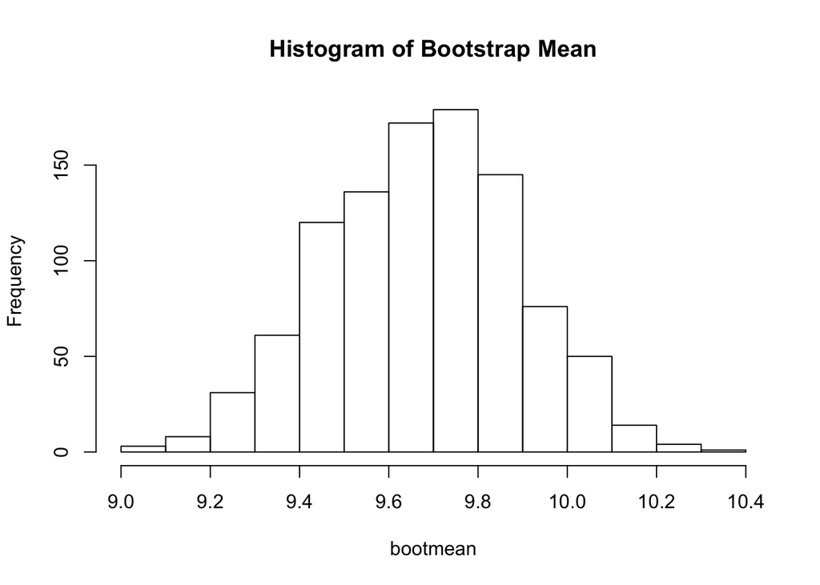

From our results we can see that the bootstrap mean is close to our original sample mean (μ) and our variance is close to σ²/N. These quantitative results exhibit the CLT at work and the normally shaped histogram is further evidence of the sampling distribution of means approaching a normal distribution

### Increasing N as evidence of CLT

The histogram of a single random sample with N=75 taken from a normal distribution with a mean (μ) of 10 and a variance (σ²) of 4 is shown below.

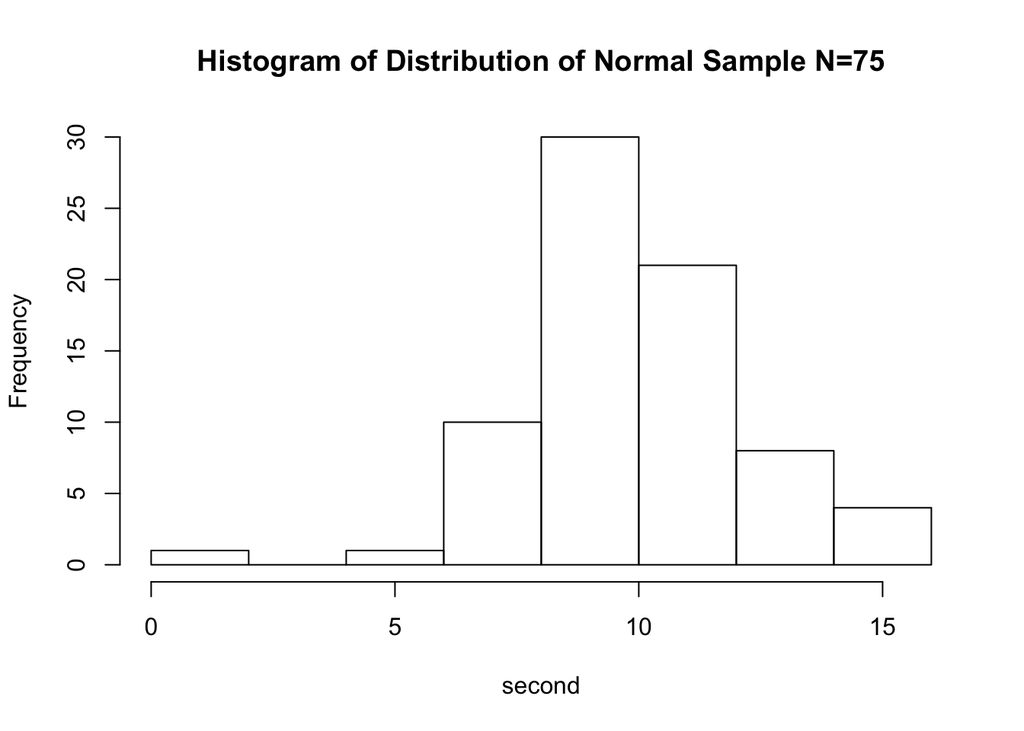

```r
#histogram of normal distribution sample 2 and bootstrap sample 2
hist(second, main="Histogram of Distribution of Normal Sample N=75")
```

We expect as N increases from 50 to 75 that the results from our bootstrap more closely adhere to a normal distribution.

```r
bstrap(second)
```

```
## [1] 9.929317
## [1] 0.0647651
```

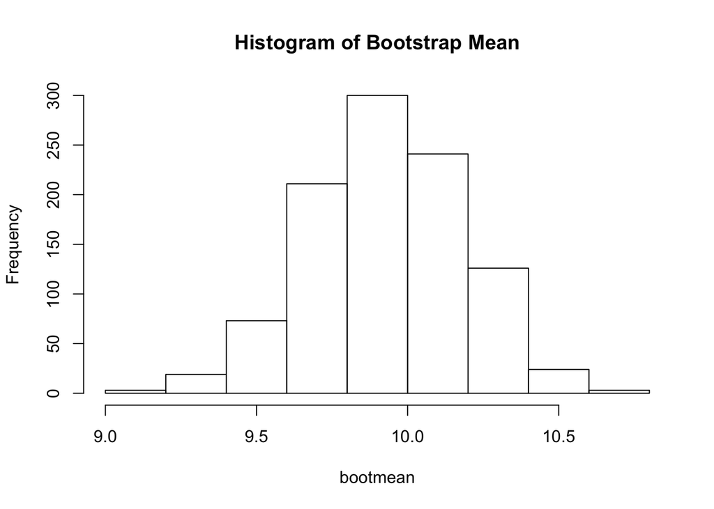

### Bootstrap for an Exponential Distribution

We run the same construct using random samples taken from an exponential distribution with rate = 1. The mean and variance of this distribution are 1 and 1 respectively.

The histogram of our random sample of the exponential distribution is below.

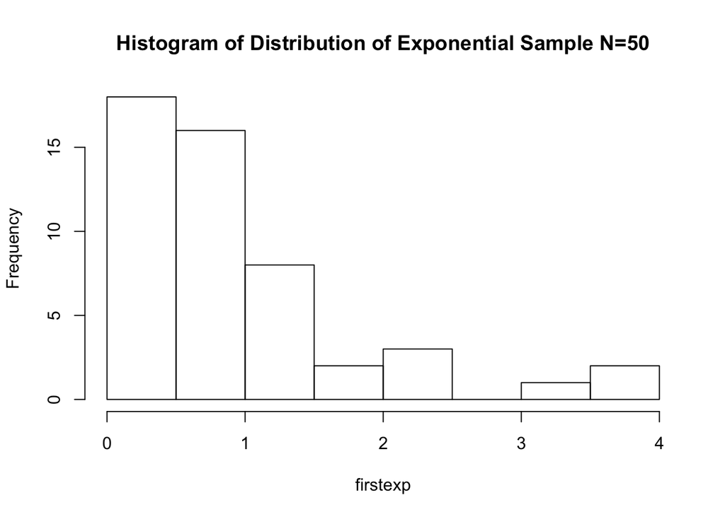

```r
#histogram of exponential distribution sample 1 and bootstrap sample 1
hist(firstexp, main="Histogram of Distribution of Exponential Sample N=50")
```

We use the bootstrap method on this data and find the mean, variance, and distribution of the sample means.

```r
bstrap(firstexp)
```

```
## [1] 0.8786658
## [1] 0.01393143
```

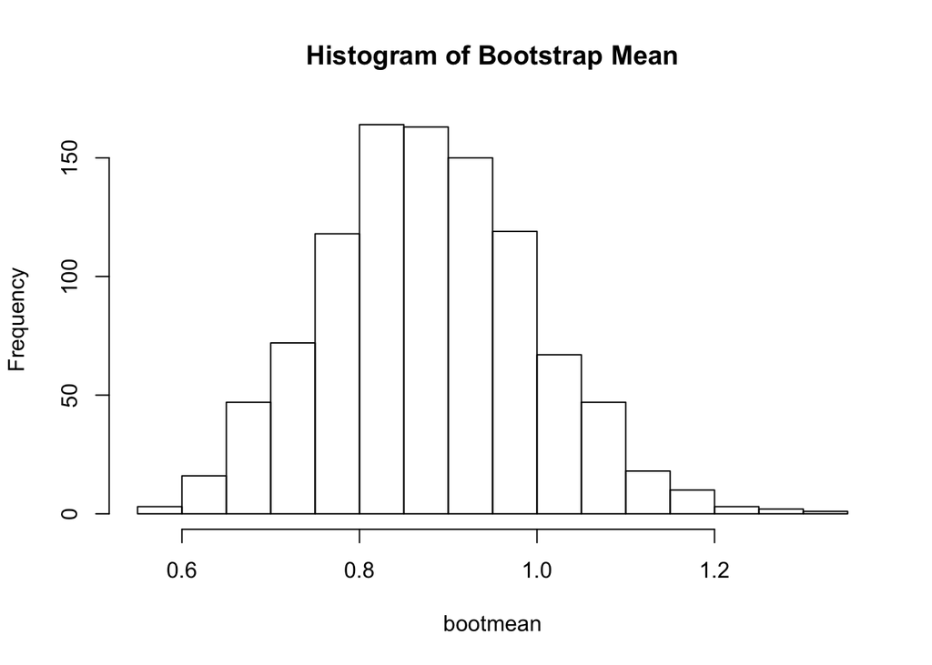

Our results show evidence of a nearly normal distribution with a mean close to μ and a variance close to σ²/N.

We run the same bootstrap on analysis on our exponential distribution with N=75.

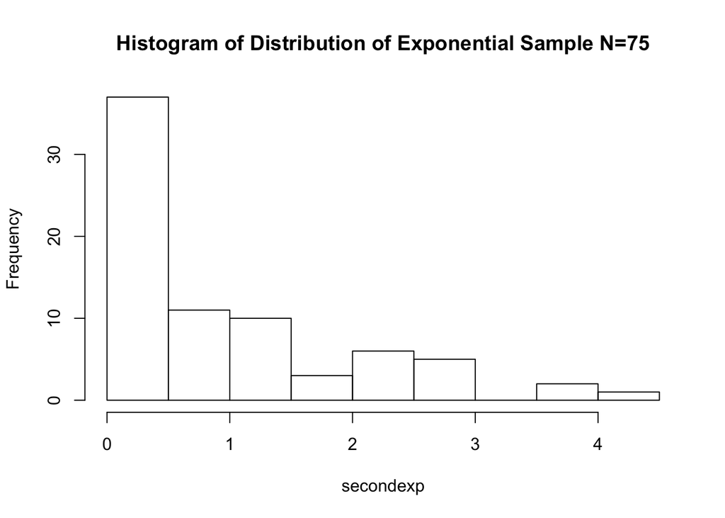

```r
#histogram of exponential distribution sample 2 and bootstrap sample 2
hist(secondexp, main="Histogram of Distribution of Exponential Sample N=75")
```

We illustrate the CLT again.

```r
bstrap(secondexp)
```

```
## [1] 0.9616939
## [1] 0.01315335
```

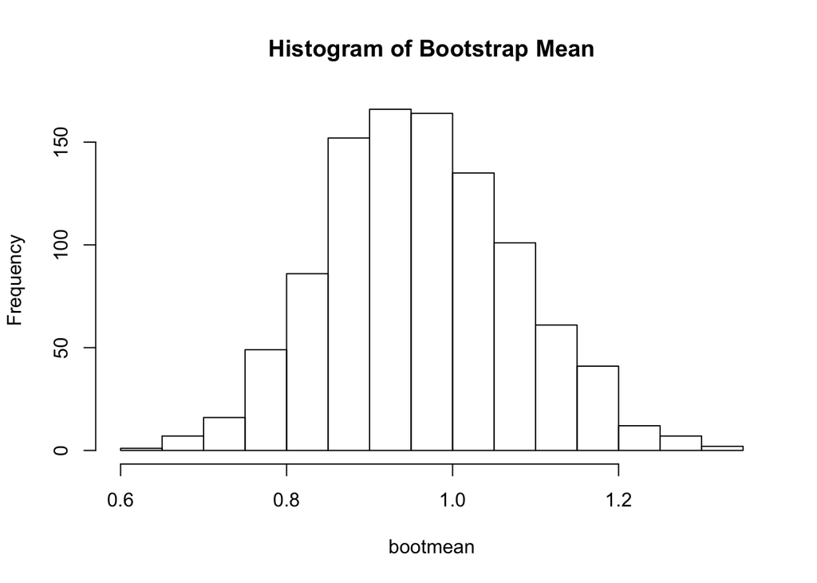

From these 4 examples we can see how the bootstrap method can provide enough iterations of our random sample to illustrate the Central Limit Theorem.